# Interpretabilidad de modelos con LIME

⚔ Para XGBoost

Andrea Olmos, Ulises López

Actualizado: 2021-12-06

# LIME

- Modelo a explicar: xgboost
- Local surrogate model: regresión lineal

# Librerías

```r
library(data.table)
library(lime)
library(caret)
library(xgboost)
library(kableExtra)
```

# Datos

Usamos datos de una campaña de marketing bancaria. Queremos predecir si un cliente va a aceptar un producto que se le ofrece por una llamada telefónica (subscribed yes o no).

Link al dataset:

[**https://www.kaggle.com/berkayalan/bank-marketing-data-set**](https://www.kaggle.com/berkayalan/bank-marketing-data-set)

```r
dataset = fread("../datasets/bank_marketing_dataset.csv", stringsAsFactors = T)
```

- Vemos un head del dataset

```r
kable(head(dataset), format="simple")
```

| age | job | marital | education | default | housing | loan | contact | month | day_of_week | duration | campaign | pdays | previous | poutcome | emp.var.rate | cons.price.idx | cons.conf.idx | euribor3m | nr.employed | subscribed |
| --- | --- | --- | --- | --- | --- | --- | --- | --- | --- | --- | --- | --- | --- | --- | --- | --- | --- | --- | --- | --- |
| 56 | housemaid | married | basic.4y | no | no | no | telephone | may | mon | 261 | 1 | 999 | 0 | nonexistent | 1.1 | 93.994 | -36.4 | 4.857 | 5191 | no |
| 57 | services | married | high.school | unknown | no | no | telephone | may | mon | 149 | 1 | 999 | 0 | nonexistent | 1.1 | 93.994 | -36.4 | 4.857 | 5191 | no |
| 37 | services | married | high.school | no | yes | no | telephone | may | mon | 226 | 1 | 999 | 0 | nonexistent | 1.1 | 93.994 | -36.4 | 4.857 | 5191 | no |
| 40 | admin. | married | basic.6y | no | no | no | telephone | may | mon | 151 | 1 | 999 | 0 | nonexistent | 1.1 | 93.994 | -36.4 | 4.857 | 5191 | no |
| 56 | services | married | high.school | no | no | yes | telephone | may | mon | 307 | 1 | 999 | 0 | nonexistent | 1.1 | 93.994 | -36.4 | 4.857 | 5191 | no |
| 45 | services | married | basic.9y | unknown | no | no | telephone | may | mon | 198 | 1 | 999 | 0 | nonexistent | 1.1 | 93.994 | -36.4 | 4.857 | 5191 | no |

# Dividimos en train y test

```r
# Dividimos el dataset con createDataPartition de caret
set.seed(3456)
inTrain = createDataPartition(
  y = dataset$subscribed, #la clase a predecir
  p = .75, #75% para train
  list = FALSE
)

# Usamos los índices para dividir entre train y test
# Recordatorio: tienen la clase a predecir
training = dataset[ inTrain,]
testing  = dataset[-inTrain,]
```

# Entrenamos xgboost con paquete Caret

```r
#Creamos la grilla de parámetros para xgbTree (los dejamos fijos por ahora)

# gbmGrid = expand.grid(
#   nrounds = 2,
#   max_depth = 3,
#   eta = 0.3,
#   gamma = 0,
#   colsample_bytree = 1,
#   min_child_weight = 1,
#   subsample = 1
# )

#Entrenamos el árbol con todas las variables
fit.xgbTree_all = train(subscribed ~ .,
                     data=training, #usamos los datos de train
                     method="xgbTree")
```

[output not shown]

[output cut: 1745 more lines]

[output not shown]

```r
#tuneGrid=gbmGrid
```

# Predecimos sobre los datos de testing

```r
predict(fit.xgbTree_all, testing)[1:200]
```

```
##   [1] no no no no no no no no no no no no no no no no no no no no no no no no no
##  [26] no no no no no no no no no no no no no no no no no no no no no no no no no
##  [51] no no no no no no no no no no no no no no no no no no no no no no no no no
##  [76] no no no no no no no no no no no no no no no no no no no no no no no no no
## [101] no no no no no no no no no no no no no no no no no no no no no no no no no
## [126] no no no no no no no no no no no no no no no no no no no no no no no no no
## [151] no no no no no no no no no no no no no no no no no no no no no no no no no
## [176] no no no no no no no no no no no no no no no no no no no no no no no no no
## Levels: no yes
```

# Vemos la matriz de confusión y las métricas de performance

```r
real_vs_pred = table(testing$subscribed, predict(fit.xgbTree_all, testing))
confusionMatrix(real_vs_pred)
```

```
## Confusion Matrix and Statistics
##
##
##         no  yes
##   no  8830  307
##   yes  538  622
##
##                Accuracy : 0.9179
##                  95% CI : (0.9125, 0.9232)
##     No Information Rate : 0.9098
##     P-Value [Acc > NIR] : 0.00182
##
##                   Kappa : 0.5505
##
##  Mcnemar's Test P-Value : 2.528e-15
##
##             Sensitivity : 0.9426
##             Specificity : 0.6695
##          Pos Pred Value : 0.9664
##          Neg Pred Value : 0.5362
##              Prevalence : 0.9098
##          Detection Rate : 0.8575
##    Detection Prevalence : 0.8873
##       Balanced Accuracy : 0.8061
##
##        'Positive' Class : no
##
```

# LIME

Pasos:

1. Dada una observación, la permuta para crear una replica con pequeñas modificaciones en sus features.
2. Computa una métrica de similaridad entre la observación original y la observación permutada.
3. Aplica el modelo complejo para predecir la salida de la observación original y las permutadas.
4. Selecciona m número de variables para describir las salidas del modelo complejo.
5. Ajusta un modelo simple a los datos permutados. Explica la salida compleja del modelo con las m variables de los datos permutados, pesados por su similaridad a la observación original.
6. Usa los pesos de cada feature para explicar el comportamiento local del modelo complejo.
- Extraido de: https://uc-r.github.io/lime

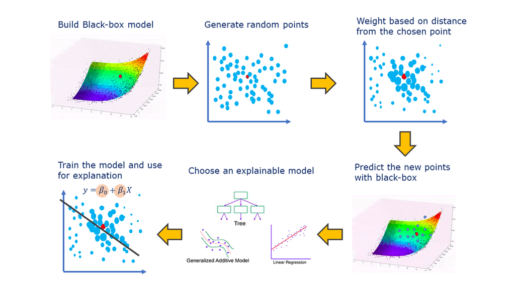

Lime

- Extraido de: https://towardsdatascience.com/lime-explain-machine-learning-predictions-af8f18189bfe

# Creamos el objeto explainer con la función lime

```r
#recibe el dataset de entrenamiento sin la clase, el modelo y el número de bins con el que se van a binnear las variables numéricas
explainer_all = lime(training[,-"subscribed"], fit.xgbTree_all,  n_bins = 5)

#objeto explainer

#contiene una lista con el modelo entrenado y las variables binneadas.
#genera una nueva función que puede ser usada para explicar las predicciones individuales del modelo caja negra.

explainer_all
```

```
## $model
## eXtreme Gradient Boosting
##
## 30891 samples
##    20 predictor
##     2 classes: 'no', 'yes'
##
## No pre-processing
## Resampling: Bootstrapped (25 reps)
## Summary of sample sizes: 30891, 30891, 30891, 30891, 30891, 30891, ...
## Resampling results across tuning parameters:
##
##   eta  max_depth  colsample_bytree  subsample  nrounds  Accuracy   Kappa
##   0.3  1          0.6               0.50        50      0.9091642  0.4426528
##   0.3  1          0.6               0.50       100      0.9114622  0.4828366
##   0.3  1          0.6               0.50       150      0.9118074  0.4896498
##   0.3  1          0.6               0.75        50      0.9086685  0.4331561
##   0.3  1          0.6               0.75       100      0.9110086  0.4750724
##   0.3  1          0.6               0.75       150      0.9118951  0.4871236
##   0.3  1          0.6               1.00        50      0.9083524  0.4267543
##   0.3  1          0.6               1.00       100      0.9107622  0.4702544
##   0.3  1          0.6               1.00       150      0.9115249  0.4808436
##   0.3  1          0.8               0.50        50      0.9090969  0.4423450
##   0.3  1          0.8               0.50       100      0.9111029  0.4801876
##   0.3  1          0.8               0.50       150      0.9116866  0.4894584
##   0.3  1          0.8               0.75        50      0.9087389  0.4360488
##   0.3  1          0.8               0.75       100      0.9108317  0.4748580
##   0.3  1          0.8               0.75       150      0.9117329  0.4873354
##   0.3  1          0.8               1.00        50      0.9085245  0.4296614
##   0.3  1          0.8               1.00       100      0.9106320  0.4690664
##   0.3  1          0.8               1.00       150      0.9114832  0.4803242
##   0.3  2          0.6               0.50        50      0.9125927  0.5005405
##   0.3  2          0.6               0.50       100      0.9135637  0.5178105
##   0.3  2          0.6               0.50       150      0.9134750  0.5202197
##   0.3  2          0.6               0.75        50      0.9130209  0.5044801
##   0.3  2          0.6               0.75       100      0.9142669  0.5217159
##   0.3  2          0.6               0.75       150      0.9142560  0.5264178
##   0.3  2          0.6               1.00        50      0.9126059  0.4967937
##   0.3  2          0.6               1.00       100      0.9139041  0.5163694
##   0.3  2          0.6               1.00       150      0.9144071  0.5243378
```

[output cut: 285 more lines]

```
## 0.2162118 0.2479039 0.1383251 0.2077628 0.1897964
##
## $feature_distribution$euribor3m
##
##         1         2         3         4         5
## 0.2082160 0.2046874 0.2061118 0.2060147 0.1749701
##
## $feature_distribution$nr.employed
##
##          1          2          3          4
## 0.32779774 0.18995824 0.08795442 0.39428960
##
##
## attr(,"class")
## [1] "data_frame_explainer" "explainer"            "list"
```

# Seleccionamos las observaciones a explicar

```r
# Seleccionamos 3 observaciones random de cada nivel de la variable a predecir
sample_no = testing[ testing[,subscribed=="no"], ][sample(nrow(testing[ testing[,subscribed=="no"], ]), 3), ]

sample_yes = testing[ testing[,subscribed=="yes"], ][sample(nrow(testing[ testing[,subscribed=="yes"], ]), 3), ]

sample_explain = rbind(sample_no, sample_yes)
kable(sample_explain)
```

| age | job | marital | education | default | housing | loan | contact | month | day_of_week | duration | campaign | pdays | previous | poutcome | emp.var.rate | cons.price.idx | cons.conf.idx | euribor3m | nr.employed | subscribed |
| --- | --- | --- | --- | --- | --- | --- | --- | --- | --- | --- | --- | --- | --- | --- | --- | --- | --- | --- | --- | --- |
| 52 | admin. | married | basic.4y | no | yes | yes | cellular | nov | mon | 102 | 3 | 999 | 0 | nonexistent | -0.1 | 93.200 | -42.0 | 4.191 | 5195.8 | no |
| 29 | admin. | single | university.degree | no | yes | no | telephone | jul | thu | 109 | 3 | 999 | 0 | nonexistent | 1.4 | 93.918 | -42.7 | 4.958 | 5228.1 | no |
| 41 | technician | married | basic.9y | no | yes | no | telephone | may | wed | 210 | 2 | 999 | 0 | nonexistent | 1.1 | 93.994 | -36.4 | 4.859 | 5191.0 | no |
| 65 | retired | married | high.school | no | yes | yes | cellular | oct | fri | 344 | 2 | 12 | 1 | success | -1.1 | 94.601 | -49.5 | 1.029 | 4963.6 | yes |
| 39 | technician | married | university.degree | no | no | yes | cellular | jun | tue | 434 | 2 | 999 | 1 | failure | -1.7 | 94.055 | -39.8 | 0.702 | 4991.6 | yes |
| 26 | admin. | married | high.school | no | yes | no | cellular | nov | mon | 432 | 5 | 999 | 0 | nonexistent | -3.4 | 92.649 | -30.1 | 0.714 | 5017.5 | yes |

# Aplicamos la función explain

```r
explanation = explain(x = sample_explain[,-"subscribed"], #explicamos las observaciones seleccionadas
                      explainer = explainer_all, #con el objeto explainer
                      n_labels = 1, #vamos a explicar nuestros 2 labels
                      n_features = 6, #cantidad de features a usar en la explicación
                      n_permutations = 5000, #cantidad de permutaciones a generar por obs
                      feature_select = "highest_weights", #método para la selección de variables
                      dist_fun = "gower", #medida de distancia entre la obs original y las permutaciones
                      kernel_width = 1.5 #ancho del kernel
                      )
#vemos el objeto
tibble::glimpse(explanation)
```

```
## Rows: 36
## Columns: 13
## $ model_type       <chr> "classification", "classification", "classification",…
## $ case             <chr> "1", "1", "1", "1", "1", "1", "2", "2", "2", "2", "2"…
## $ label            <chr> "no", "no", "no", "no", "no", "no", "no", "no", "no",…
## $ label_prob       <dbl> 0.9939918, 0.9939918, 0.9939918, 0.9939918, 0.9939918…
## $ model_r2         <dbl> 0.08193063, 0.08193063, 0.08193063, 0.08193063, 0.081…
## $ model_intercept  <dbl> 0.82863316, 0.82863316, 0.82863316, 0.82863316, 0.828…
## $ model_prediction <dbl> 0.9938307, 0.9938307, 0.9938307, 0.9938307, 0.9938307…
## $ feature          <chr> "duration", "pdays", "euribor3m", "age", "emp.var.rat…
## $ feature_value    <dbl> 102.000, 999.000, 4.191, 52.000, -0.100, 0.000, 109.0…
## $ feature_weight   <dbl> 0.15240685, 0.09979567, 0.05630547, -0.05361347, -0.0…
## $ feature_desc     <chr> "88 < duration <= 145", "799 < pdays", "1.30 < euribo…
## $ data             <list> [52, admin., married, basic.4y, no, yes, yes, cellul…
## $ prediction       <list> [0.9939918, 0.006008208], [0.9939918, 0.006008208], …
```

```r
#Documentación:
#https://github.com/thomasp85/lime/blob/master/R/explain.R

# A data.frame encoding the explanations one row per explained observation. The columns are:
# model_type: The type of the model used for prediction.
# case: The case being explained (the rowname in cases).
# model_r2: The quality of the model used for the explanation
# model_intercept: The intercept of the model used for the explanation
# model_prediction: The prediction of the observation based on the model used for the explanation.
# feature: The feature used for the explanation
# feature_value: The value of the feature used
# feature_weight: The weight of the feature in the explanation
# feature_desc: A human readable description of the feature importance.
# data: Original data being explained
# prediction: The original prediction from the model
# Furthermore classification explanations will also contain:
# label: The label being explained
# label_prob: The probability of label as predicted by model
```

# Ploteamos las features

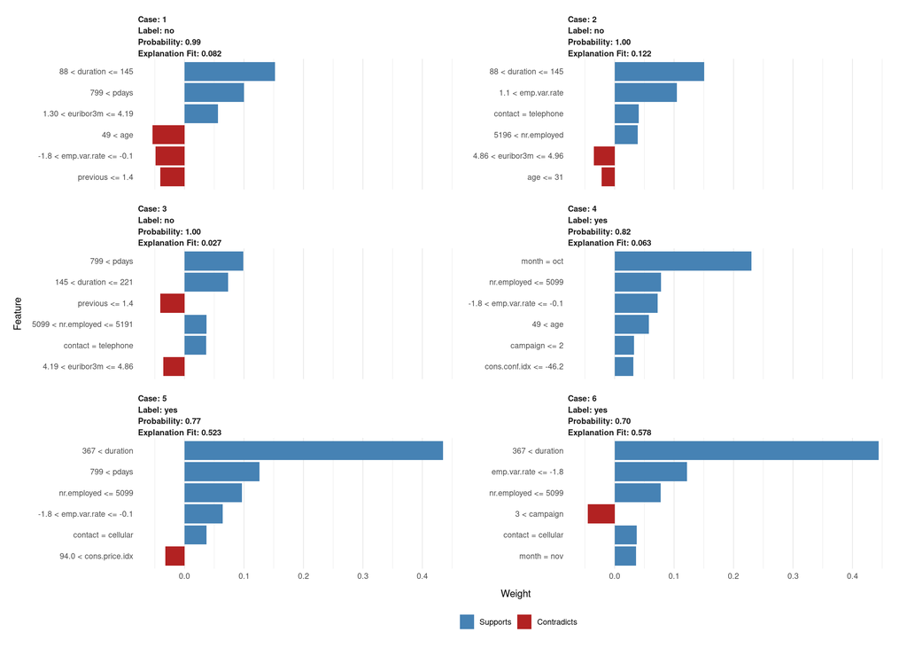

```r
# And can be visualised directly
plot_features(explanation)
```

# Ploteamos las explanations

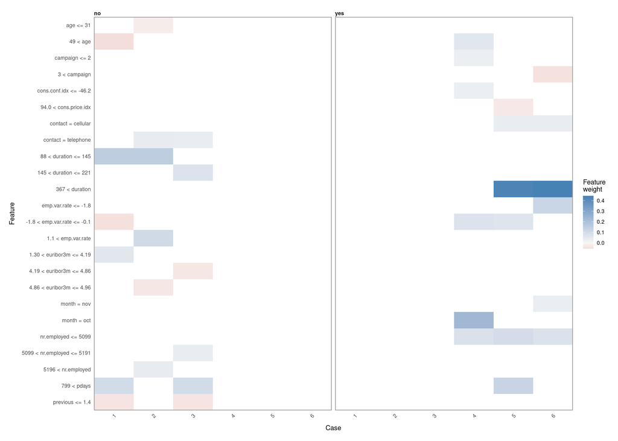

```r
plot_explanations(explanation)
```

# Probamos otros valores de kernel width

Creamos un dataset sólo con variables numéricas (para poder probar otras medidas de distancia)

```r
#creamos una máscara para poder seleccionar sólo las variables numéricas
mascara = lapply(dataset, FUN=is.numeric)
mascara = unlist(mascara, use.names = F)
mascara[21] = TRUE #para que se quede con la variable a predecir
```

Entrenamos el árbol con sólo las variables numéricas

```r
fit.xgbTree_num = train(subscribed ~ .,
                     data=training[, ..mascara], #usamos los datos de train mascareados
                     method="xgbTree")
```

[output not shown]

[output cut: 1745 more lines]

[output not shown]

```r
predict(fit.xgbTree_num, testing)[1:200]
```

```
##   [1] no  no  no  no  no  no  no  no  no  yes no  no  no  no  no  no  no  no
##  [19] no  no  no  no  no  no  no  no  no  no  no  no  no  no  no  no  no  no
##  [37] no  no  no  no  no  no  no  no  no  no  no  no  no  no  no  no  no  no
##  [55] no  no  no  no  no  no  no  no  no  no  no  no  no  no  no  no  no  no
##  [73] no  no  no  no  no  no  no  no  no  no  no  no  no  no  no  no  no  no
##  [91] no  no  no  no  no  no  no  no  no  no  no  no  no  no  no  no  no  no
## [109] no  no  no  no  no  no  no  no  no  no  no  no  no  no  no  no  no  no
## [127] no  no  no  no  no  no  no  no  no  no  no  no  no  no  no  no  no  no
## [145] no  no  no  no  no  no  no  no  no  no  no  no  no  no  no  no  no  no
## [163] no  no  no  no  no  no  no  no  no  no  no  no  no  no  no  no  no  no
## [181] no  no  no  no  no  no  no  no  no  no  no  no  no  no  no  no  no  no
## [199] no  no
## Levels: no yes
```

- Vemos la matriz de confusión para el modelo de sólo numéricas

```r
real_vs_pred_num = table(testing$subscribed, predict(fit.xgbTree_num, testing))
confusionMatrix(real_vs_pred_num)
```

```
## Confusion Matrix and Statistics
##
##
##         no  yes
##   no  8839  298
##   yes  555  605
##
##                Accuracy : 0.9172
##                  95% CI : (0.9117, 0.9224)
##     No Information Rate : 0.9123
##     P-Value [Acc > NIR] : 0.04143
##
##                   Kappa : 0.5413
##
##  Mcnemar's Test P-Value : < 2e-16
##
##             Sensitivity : 0.9409
##             Specificity : 0.6700
##          Pos Pred Value : 0.9674
##          Neg Pred Value : 0.5216
##              Prevalence : 0.9123
##          Detection Rate : 0.8584
##    Detection Prevalence : 0.8873
##       Balanced Accuracy : 0.8055
##
##        'Positive' Class : no
##
```

# Aplicamos LIME

- Generamos el objeto explainer

```r
explainer_num = lime(training[, ..mascara][,-"subscribed"],
                     fit.xgbTree_num,
                     bin_continuous = TRUE)
```

# Prueba 1: la misma semilla con distintos valores de kernel width

- Aplicamos el explain para la 3ra observación
- Utilizamos la misma semilla para las permutaciones
- Cambiamos el valor del kernel width

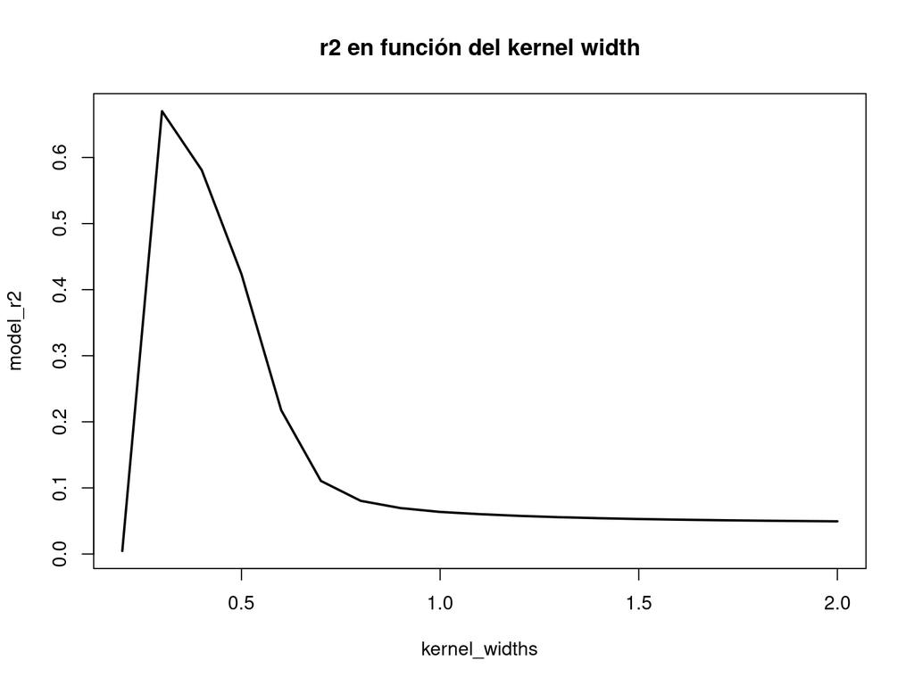

```r
#mascareamos a los samples
sample_explain_num = sample_explain[ , ..mascara]

#hacemos vector con los distintos kernels width a probar
#kernel_widths = c(0.1, 0.2, 0.3, 0.4, 0.5, 1, 1.5, 2, 3)
kernel_widths = seq(0.2, 2, by=0.1)

#vector para guardar los r2
model_r2 = c()

#iteramos sobre los kernels width
for (i in kernel_widths){
  #dejamos fija la semilla para que sean las mismas permutaciones en cada iteración
  set.seed(123)
  explanation = explain(x = sample_explain_num[3,-"subscribed"], #explicamos las observaciones seleccionadas
                      explainer = explainer_num, #con el objeto explainer
                      n_labels = 1, #vamos a explicar nuestros 2 labels
                      n_features = 6, #cantidad de features a usar en la explicación
                      n_permutations = 5000, #cantidad de permutaciones a generar por obs
                      feature_select = "highest_weights", #método para la selección de variables
                      dist_fun = "euclidean", #medida de distancia entre la obs original y las permutaciones
                      kernel_width = i #ancho del kernel
                      )

  model_r2 = append(model_r2, explanation$model_r2[1])

}

plot(kernel_widths, model_r2, "l", lwd=2, main="r2 en función del kernel width")
```

Resultado: modelos sustitutos con distintos valores de r2.

# Prueba 2: distintas semillas con el mismo valor de kernel width

- Aplicamos el explain para la 3ra observación
- Utilizamos distintas semillas para las permutaciones
- Utilizamos el mismo kernel width

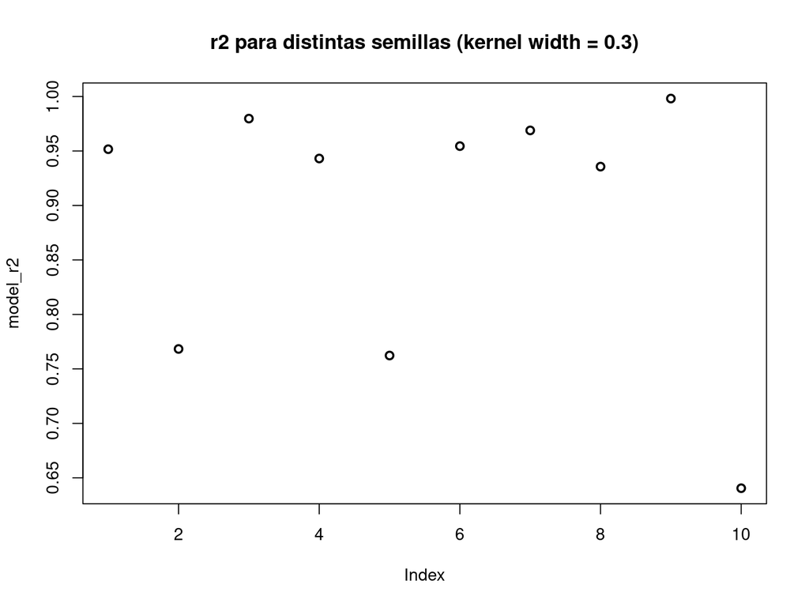

```r
options(scipen = 999)
#fijamos el kernel width en 0.3
kernel_widths = rep(0.3, 10)
model_r2 = c()

for (i in kernel_widths){
  explanation = explain(x = sample_explain_num[3,-"subscribed"], #explicamos las observaciones seleccionadas
                      explainer = explainer_num, #con el objeto explainer
                      n_labels = 1, #vamos a explicar nuestros 2 labels
                      n_features = 6, #cantidad de features a usar en la explicación
                      n_permutations = 5000, #cantidad de permutaciones a generar por obs
                      feature_select = "highest_weights", #método para la selección de variables
                      dist_fun = "euclidean", #medida de distancia entre la obs original y las permutaciones
                      kernel_width = i #ancho del kernel
                      )

  model_r2 = append(model_r2, explanation$model_r2[1])

}

plot(model_r2, lwd=2, main="r2 para distintas semillas (kernel width = 0.3)")
```

Resultado: modelos sustitutos con distintos valores de r2.